# Part II - (2_2019_Fordge_bike_dataset)

## by (Kafayat Ibrahim)

## Investigation Overview

> In this analysis i would like to investigate on what time of the day, days of the week the trip take place,and the station with more activities. also to find out on how attribute such as (age,sex,usertype and trip duration) contributed to the activities of the location and time group

## Dataset Overview

> The 201902-fordgobike-tripdata is all about the information for february 2019 fordgo bike trip the data provided contain 16 columns with about 183412.two date time columns,which include start date and end date column. the data set has two location which are start_station, and end_station, user attributes. start and end latitude, longitute. Although i use the subset data of the top 7 station name data for my analysis

## (Visualization 1)

### Investigate trip frequency with time properties

> Trip made by 8am in the morning and 5pm in evening has highest counts due to rushing hours to work and after close of work

> Morning and afternoon has higher trip count compare to the night, generally morning and afternoon has more trips according to hour plot plot

> Weekdays trips has higher counts than weekend trips, majority of the riders used it on working days.

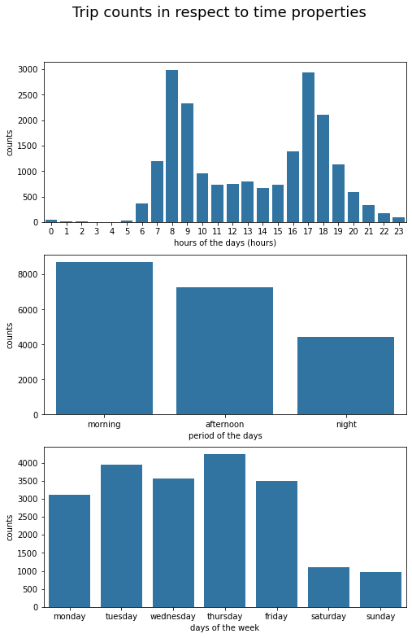

### The trip distribution of with Gender and user type

> The male counts is three times female counts

> The trips counts by subscribers is more than the trip made by customers user type

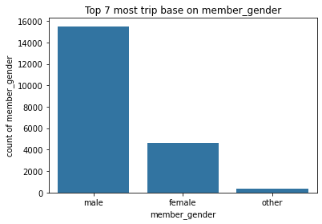

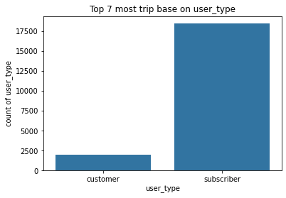

### Distribution of trips across the top 7 stations

> The top 7 stations is located in San fransisco and conneted to the public Transportation, including Bart, Caltrain and ferry

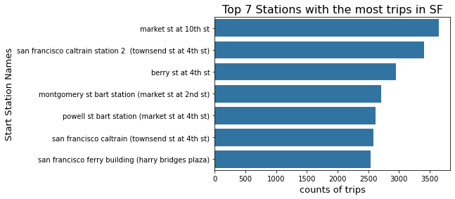

## (Visualization 2)

#### Investigate the top seven station with time group

> Half of the stations has most trip count in the morning and the second half has most trip count in the afternoon

> Generally there are mor trips during the weekdays than week end across the top 7 stations

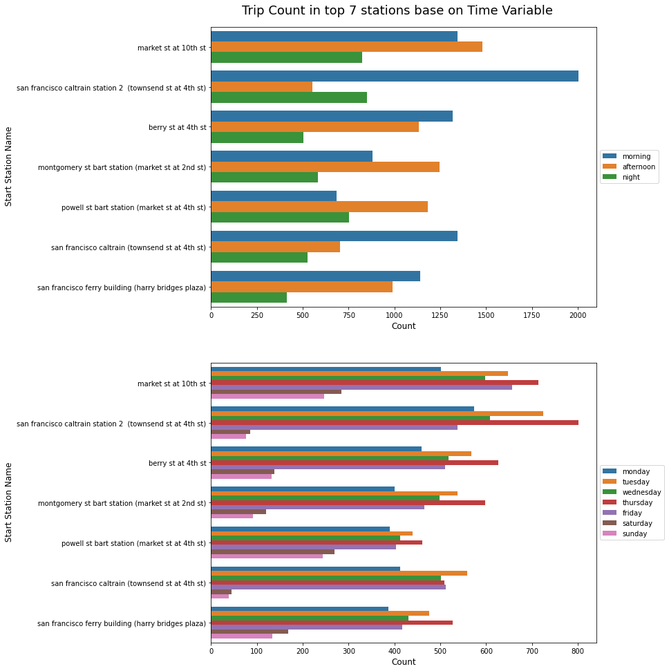

## (Visualization 3)

#### Investigate the top seven station base on user types with time group

> the subscribers user type has more trips during the week days across the top 7 stations

[figure not shown]

### Customers trip duration across the top 7 stations base on time group

> powell st bart station (market st at 4th st) and san francisco ferry building (harry bridges plaza) stations has longer trip duration in the morning afternoon and night

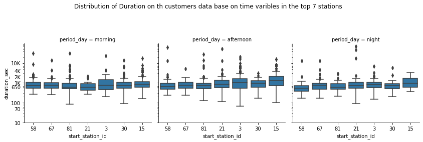

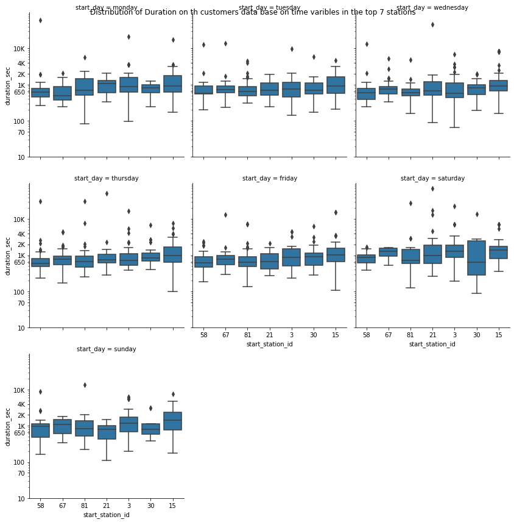

### Subscribers trip duration across the top 7 stations base on time group

> Generally the average trip durations across the top 7 station with subscribers is 650 seconds.

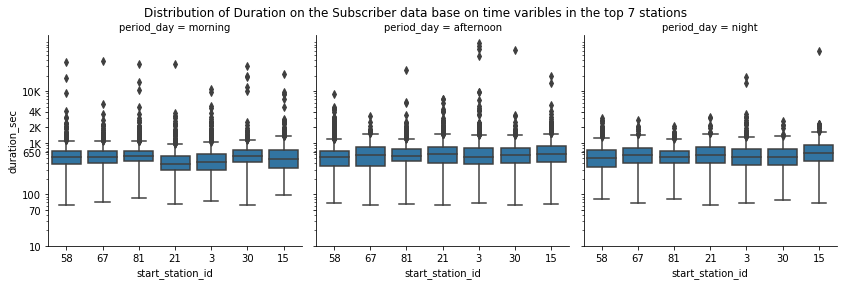

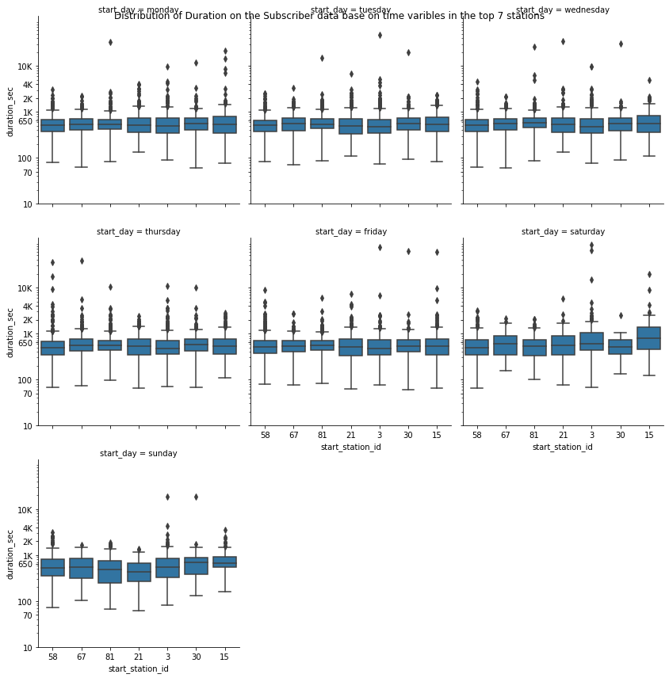